# How do we Publish our Package?

Now we know the ‘why’, let’s deep dive into the ‘how’. The second part of this article steps through the creation of a very simple arithmetic package. While the article frames up how to do this into a private repository, I’ve actually published mine to a public repository so you can `pip install` it yourself and test it out without having to build it yourself if you don’t want to. You’ll find the repository [here](https://github.com/nydasco/package_publishing).

## Prerequisites

Before we start, ensure you have:

- Basic knowledge of Python programming.
- Python 3.6 or higher installed.
- `pip` installed.

## Step 1: Set Up Your Project Structure

A well-organised project structure is crucial, as the intention here is that this is a package that will out live individual projects and be maintained for many years, potentially by multiple teams. You need to ensure you have tests, and clear documentation. Here’s a basic template:

[figure not shown]

- `package_publishing/` is the root directory.
- `package_publishing/` contains your package modules.
- `tests/` contains your test cases.
- `setup.py` is the script for building and distributing the package.
- `README.md` is a description of your package.
- `LICENSE` specifies the license under which your package is distributed.

I’d note that for simplicity I’m writing this package without OOP design. I’ve simply written some functions within module files. However if you’re package is going to become fairly complex, I would recommend thinking about the approach you take from the outset.

## Step 2: Writing Your Package Code

Obviously your package isn’t going to be much use if it doesn’t do anything. I’ve created two basic modules. The first can do addition and subtraction, while the second can do multiplication and division.

Create `package_publishing/module1.py`:

```
# package_publishing/module1.py

def add(a, b):
    return a + b

def subtract(a, b):
    return a - b
```

And `package_publishing/module2.py`:

```
# package_publishing/module2.py

def multiply(a, b):
    return a * b

def divide(a, b):
    if b == 0:
        raise ValueError("Cannot divide by zero.")
    return a / b
```

## Step 3: Creating `__init__.py`

The `__init__.py` file makes Python treat the directory as a package. Create `package_publishing/__init__.py`:

```
# package_publishing/__init__.py

from .module1 import add, subtract
from .module2 import multiply, divide
```

## Step 4: Writing Tests

Testing ensures your package works as expected. Create `tests/test_module1.py`:

```
# tests/test_module1.py

import unittest
from package_publishing import add, subtract

class TestModule1(unittest.TestCase):

    def test_add(self):
        self.assertEqual(add(1, 2), 3)
        self.assertEqual(add(-1, 1), 0)

    def test_subtract(self):
        self.assertEqual(subtract(2, 1), 1)
        self.assertEqual(subtract(2, 3), -1)

if __name__ == "__main__":
    unittest.main()
```

## Step 5: Creating `setup.py`

The `setup.py` file is essential for packaging. Create `setup.py`:

```
from setuptools import setup, find_packages

setup(
    name="package_publishing",
    version="0.1",
    packages=find_packages(),
    install_requires=[],
    author="Andy",
    author_email="andy@dont_spam_me.co",
    description="A simple example private package",
    long_description=open("README.md").read(),
    long_description_content_type="text/markdown",
    url="https://github.com/nydasco/package_publishing",
    classifiers=[
        "Programming Language :: Python :: 3",
        "License :: OSI Approved :: MIT License",
        "Operating System :: OS Independent",
    ],
    python_requires='>=3.6',
)
```

## Step 6: Writing the README and LICENSE

Your `README.md` should provide an overview of your package:

````
# My Package

A simple example package.

## Installation

```bash
pip install package_publishing
````

## Step 7: Building and Distributing Your Package

To build your package, run:

```
pip install wheel
python setup.py sdist bdist_wheel
```

This creates a `dist/` directory with the distribution files.

## Step 8. Initialize Git and Push to GitHub

In your project directory, run the following commands to initialize a Git repository, add your files, commit them, and push to GitHub:

```
git init
git add .
git commit -m "Initial commit"
git remote add origin https://github.com/yourusername/package_publishing.git
git push -u origin main
```

Replace `yourusername` with your GitHub username and `package_publishing` with your repository name.

# Using Your Package

Now that you’ve published your package, you’ll want to use it. First thing to do if your code sits in a private repository is to create yourself a personal access token. Follow these steps to generate a PAT:

1. Go to [GitHub Settings](https://github.com/settings/profile).
2. Select “Developer settings” > “Personal access tokens”.
3. Select ‘Tokens (classic)”
4. Click “Generate new token” > “Generate new token (classic)”
5. Select the scopes you need (e.g., `repo`), and give the token a Note
6. Click “Generate token” and copy the token.

You can now use this token to install your package:

```
pip install git+https://<your-token>@github.com/yourusername/package_publishing.git
```

Replace `<your-token>` with your PAT, `yourusername` with your GitHub username, and `package_publishing` with your repository name.

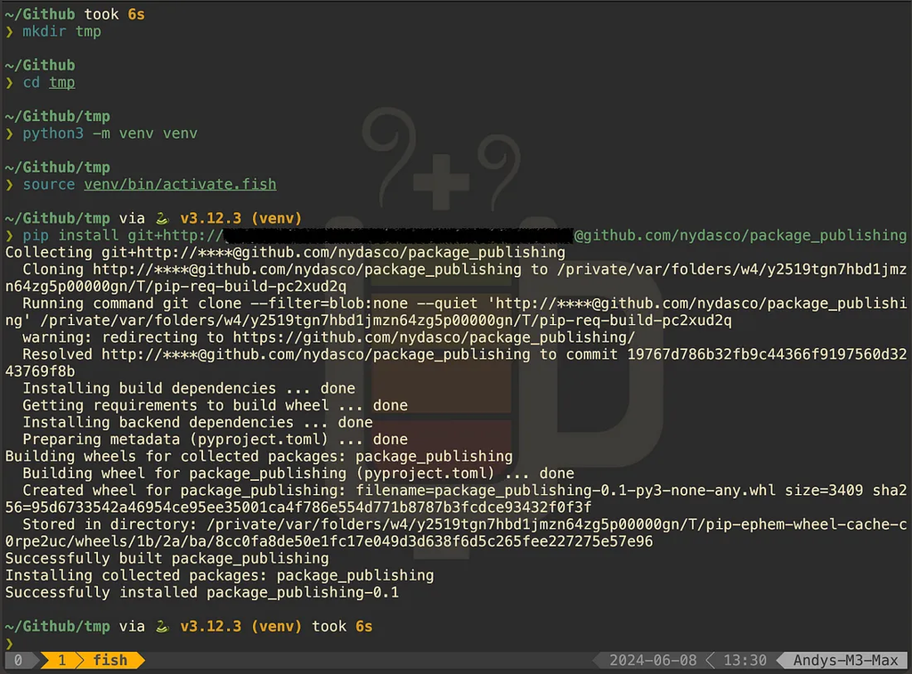

pip install from personal repository

The above screenshot shows me performing a `pip install` into a Python virtual environment of my example package.

## Keeping Your Repository Secure

Ensure that sensitive information (like your PAT) is not included in your code or shared with others. Use environment variables to manage credentials securely.

# Usage

Once you `pip install` your package, you can use it in exactly the same manner as any other package that you may have downloaded. Simply import it into your Python file:

[output not shown]

[figure not shown]

# Conclusion

Publishing Python projects as packages offers significant benefits for data engineers. It promotes code reusability, modularity, and ease of distribution. Packaging enables effective version control, dependency management, and collaboration within teams and the wider business. It also enhances discoverability.

Whether publishing to a private repository or a public package index like PyPI, packaging your Python is a great way to share your work and make it reusable. By following these steps, you can create a package, test it, and publish it into your private repository. Happy coding!